# ESTADISTICA PARA EL ANALISIS POLITICO II

- Profesor: [Dr. José Manuel Magallanes, Ph.D.](http://www.pucp.edu.pe/profesor/jose-manuel-magallanes/)
  - Profesor del Departamento de Ciencias Sociales, Sección de Ciencia Política y Gobierno.
  - [Oficina 105](https://goo.gl/maps/xuGeG6o9di1i1y5m6) - Edificio CISEPA / ECONOMIA / CCSS
  - Telefono: (51) 1 - 6262000 anexo 4302
  - Correo Electrónico: jmagallanes@pucp.edu.pe

## Análisis Factorial II: Confirmación

La vez pasada descargamos varios indicadores de estos links:

- https://en.wikipedia.org/wiki/World_Happiness_Report
- https://en.wikipedia.org/wiki/Democracy_Index

La data la colectamos y preparamos así:

```r
library(htmltab)

# links
happyL=c("https://en.wikipedia.org/wiki/World_Happiness_Report",
         '//*[@id="mw-content-text"]/div/table/tbody')
demoL=c("https://en.wikipedia.org/wiki/Democracy_Index",
        '//*[@id="mw-content-text"]/div/table[2]/tbody')

# carga
happy = htmltab(doc = happyL[1],which  = happyL[2],encoding = "UTF-8")
demo  = htmltab(doc = demoL[1], which  = demoL[2], encoding = "UTF-8")

# limpieza

happy[,]=lapply(happy[,], trimws,whitespace = "[\\h\\v]") # no blanks
demo[,]=lapply(demo[,], trimws,whitespace = "[\\h\\v]") # no blanks

library(stringr) # nombres simples
names(happy)=str_split(names(happy)," ",simplify = T)[,1]
names(demo)=str_split(names(demo)," ",simplify = T)[,1]


## Formateo

# Eliminemos columnas que no usaremos esta vez:
happy$Overall=NULL
demo[,c(1,9,10)]=NULL
happy$Score=NULL
demo$Score=NULL


# Tipo de variables:

## En demo:
demo[,-c(1)]=lapply(demo[,-c(1)],as.numeric)

# En happy:
happy[,-c(1)]=lapply(happy[,-c(1)],as.numeric)

# sin perdidos:
happy=na.omit(happy)
demo=na.omit(demo)

HappyDemo=merge(happy,demo)
```

## 1. Encontrando indices a partir de indicadores

Usando [EFA](https://htmlpreview.github.io/?https://github.com/PoliticayGobiernoPUCP/estadistica_anapol2/blob/master/efa.html) obtuvimos:

```r
library(psych)
theData=HappyDemo[,-c(1,2,9)] # sin los Scores ni nombre de país

library(GPArotation)
resfa <- fa(theData,nfactors = 3,cor = 'mixed',rotate = "varimax",fm="minres")
```

```
##
## mixed.cor is deprecated, please use mixedCor.
```

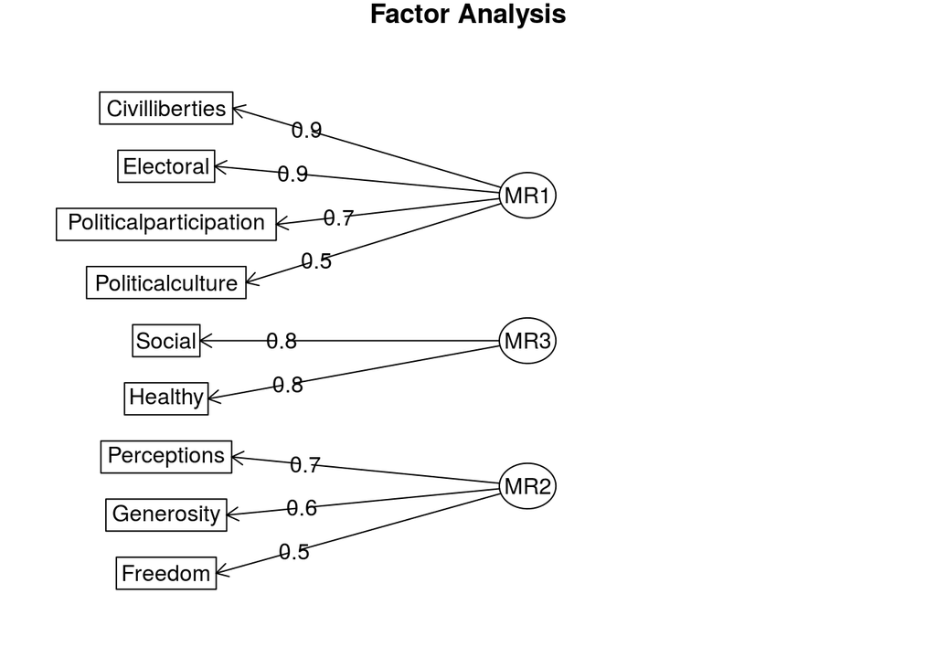

```r
fa.diagram(resfa)
```

## 2. Confirmando modelo teórico

Si la exploración apoyaba nuestro marco teórico, podemos proponer cómo construir los indices:

```r
model <- ' democracia  =~ Electoral + Functioning + Politicalparticipation + Politicalculture + Civilliberties
           tranquilidad =~ Freedom + Generosity + Perceptions
           bienestar   =~ GDP + Social + Healthy'
```

Ahora vemos qué arroja el modelo:

```r
# normalizar las variables:
HappyDemo=scale(HappyDemo[,-1])

library(lavaan)
cfa_fit <- cfa(model, data=HappyDemo,
           std.lv=TRUE,
           missing="fiml")
```

Preparo los tests:

```r
allParamCFA=parameterEstimates(cfa_fit,standardized = T)
allFitCFA=as.list(fitMeasures(cfa_fit))
```

Veamos resultados:

- Si cada indicador tiene una buena conexión con su latente (ver p valor):

```r
library(knitr)
kable(allParamCFA[allParamCFA$op=="=~",])
```

| lhs | op | rhs | est | se | z | pvalue | ci.lower | ci.upper | std.lv | std.all | std.nox |
| --- | --- | --- | --- | --- | --- | --- | --- | --- | --- | --- | --- |
| democracia | =~ | Electoral | 0.9085974 | 0.0632752 | 14.359449 | 0.0000000 | 0.7845802 | 1.0326145 | 0.9085974 | 0.9117032 | 0.9117032 |
| democracia | =~ | Functioning | 0.8753830 | 0.0654118 | 13.382651 | 0.0000000 | 0.7471783 | 1.0035878 | 0.8753830 | 0.8783754 | 0.8783754 |
| democracia | =~ | Politicalparticipation | 0.8000531 | 0.0685286 | 11.674735 | 0.0000000 | 0.6657395 | 0.9343666 | 0.8000531 | 0.8027880 | 0.8027880 |
| democracia | =~ | Politicalculture | 0.6589587 | 0.0738727 | 8.920192 | 0.0000000 | 0.5141709 | 0.8037466 | 0.6589587 | 0.6612115 | 0.6612115 |
| democracia | =~ | Civilliberties | 0.9699823 | 0.0602531 | 16.098471 | 0.0000000 | 0.8518885 | 1.0880762 | 0.9699823 | 0.9732980 | 0.9732980 |
| tranquilidad | =~ | Freedom | 0.7765672 | 0.1125121 | 6.902076 | 0.0000000 | 0.5560475 | 0.9970870 | 0.7765672 | 0.7792220 | 0.7792220 |
| tranquilidad | =~ | Generosity | 0.3258246 | 0.0982069 | 3.317737 | 0.0009075 | 0.1333426 | 0.5183066 | 0.3258246 | 0.3269387 | 0.3269387 |
| tranquilidad | =~ | Perceptions | 0.6151618 | 0.1099255 | 5.596171 | 0.0000000 | 0.3997118 | 0.8306118 | 0.6151618 | 0.6172647 | 0.6172647 |
| bienestar | =~ | GDP | 0.9154278 | 0.0642422 | 14.249629 | 0.0000000 | 0.7895154 | 1.0413403 | 0.9154278 | 0.9185570 | 0.9185570 |
| bienestar | =~ | Social | 0.8098664 | 0.0690548 | 11.727876 | 0.0000000 | 0.6745214 | 0.9452114 | 0.8098664 | 0.8126348 | 0.8126348 |
| bienestar | =~ | Healthy | 0.9168715 | 0.0642156 | 14.278020 | 0.0000000 | 0.7910113 | 1.0427318 | 0.9168715 | 0.9200057 | 0.9200057 |

Averigüemos qué tan bien salió el modelo:

- El ChiSquare es NO significativo (p_value debe ser mayor a 0.05 para que sea bueno)?

```r
allFitCFA[c("chisq", "df", "pvalue")] # pvalue>0.05
```

```
## $chisq
## [1] 217.647
##
## $df
## [1] 41
##
## $pvalue
## [1] 0
```

- El Índice Tucker Lewi es mayor a 0.9?

```r
allFitCFA$tli # > 0.90
```

```
## [1] 0.8144751
```

- La Raíz del error cuadrático medio de aproximación es menor a 0.05?

```r
allFitCFA[c('rmsea.ci.lower','rmsea' ,'rmsea.ci.upper')] # 0.05 en el Int de Conf?
```

```
## $rmsea.ci.lower
## [1] 0.1491998
##
## $rmsea
## [1] 0.1711995
##
## $rmsea.ci.upper
## [1] 0.1939246
```

Ya sabemos que no hay buen augurio.

Añadimos los índices a la data de indicadores:

```r
HappyDemo=as.data.frame(cbind(HappyDemo,lavPredict(cfa_fit)))
```

Veamos un resumen:

```r
summary(HappyDemo)
```

```
##       GDP              Social           Healthy           Freedom
##  Min.   :-2.2846   Min.   :-4.0897   Min.   :-2.7303   Min.   :-2.7861
##  1st Qu.:-0.7800   1st Qu.:-0.5401   1st Qu.:-0.7556   1st Qu.:-0.6008
##  Median : 0.1653   Median : 0.2558   Median : 0.2748   Median : 0.1606
##  Mean   : 0.0000   Mean   : 0.0000   Mean   : 0.0000   Mean   : 0.0000
##  3rd Qu.: 0.8103   3rd Qu.: 0.7948   3rd Qu.: 0.6434   3rd Qu.: 0.7950
##  Max.   : 1.9509   Max.   : 1.3640   Max.   : 1.7364   Max.   : 1.6621
##    Generosity        Perceptions        Electoral        Functioning
##  Min.   :-1.91390   Min.   :-1.1659   Min.   :-1.8299   Min.   :-2.0226
##  1st Qu.:-0.78374   1st Qu.:-0.6736   1st Qu.:-0.7985   1st Qu.:-0.7383
##  Median :-0.08706   Median :-0.2755   Median : 0.2566   Median : 0.1218
##  Mean   : 0.00000   Mean   : 0.0000   Mean   : 0.0000   Mean   : 0.0000
##  3rd Qu.: 0.68702   3rd Qu.: 0.3163   3rd Qu.: 0.8725   3rd Qu.: 0.6939
##  Max.   : 3.92786   Max.   : 3.5791   Max.   : 1.1171   Max.   : 1.8341
##  Politicalparticipation Politicalculture  Civilliberties
##  Min.   :-2.32493       Min.   :-2.2947   Min.   :-2.31202
##  1st Qu.:-0.81327       1st Qu.:-0.7895   1st Qu.:-0.83875
##  Median : 0.09481       Median :-0.0369   Median : 0.07144
##  Mean   : 0.00000       Mean   : 0.0000   Mean   : 0.00000
##  3rd Qu.: 0.69838       3rd Qu.: 0.5260   3rd Qu.: 0.86593
##  Max.   : 2.50910       Max.   : 2.5942   Max.   : 1.54471
##    democracia       tranquilidad        bienestar
##  Min.   :-2.1743   Min.   :-2.13519   Min.   :-2.8512
##  1st Qu.:-0.8670   1st Qu.:-0.60216   1st Qu.:-0.6455
##  Median : 0.1256   Median :-0.02197   Median : 0.1310
##  Mean   : 0.0000   Mean   : 0.00000   Mean   : 0.0000
##  3rd Qu.: 0.8356   3rd Qu.: 0.45455   3rd Qu.: 0.7281
##  Max.   : 1.6420   Max.   : 1.97426   Max.   : 1.6162
```

Ahora podemos correr una regresión con los índices:

```r
summary(lm(democracia~tranquilidad+bienestar,data = HappyDemo))
```

```
##
## Call:
## lm(formula = democracia ~ tranquilidad + bienestar, data = HappyDemo)
##
## Residuals:
##     Min      1Q  Median      3Q     Max
## -2.0236 -0.3104  0.2348  0.5011  1.2886
##
## Coefficients:
##                Estimate Std. Error t value Pr(>|t|)
## (Intercept)  -3.243e-17  6.088e-02   0.000    1.000
## tranquilidad  1.142e-01  9.133e-02   1.250    0.213
## bienestar     6.147e-01  8.059e-02   7.627 2.99e-12 ***
## ---
## Signif. codes:  0 '***' 0.001 '**' 0.01 '*' 0.05 '.' 0.1 ' ' 1
##
## Residual standard error: 0.7382 on 144 degrees of freedom
## Multiple R-squared:  0.4481, Adjusted R-squared:  0.4404
## F-statistic: 58.46 on 2 and 144 DF,  p-value: < 2.2e-16
```

Sólo para verificar:

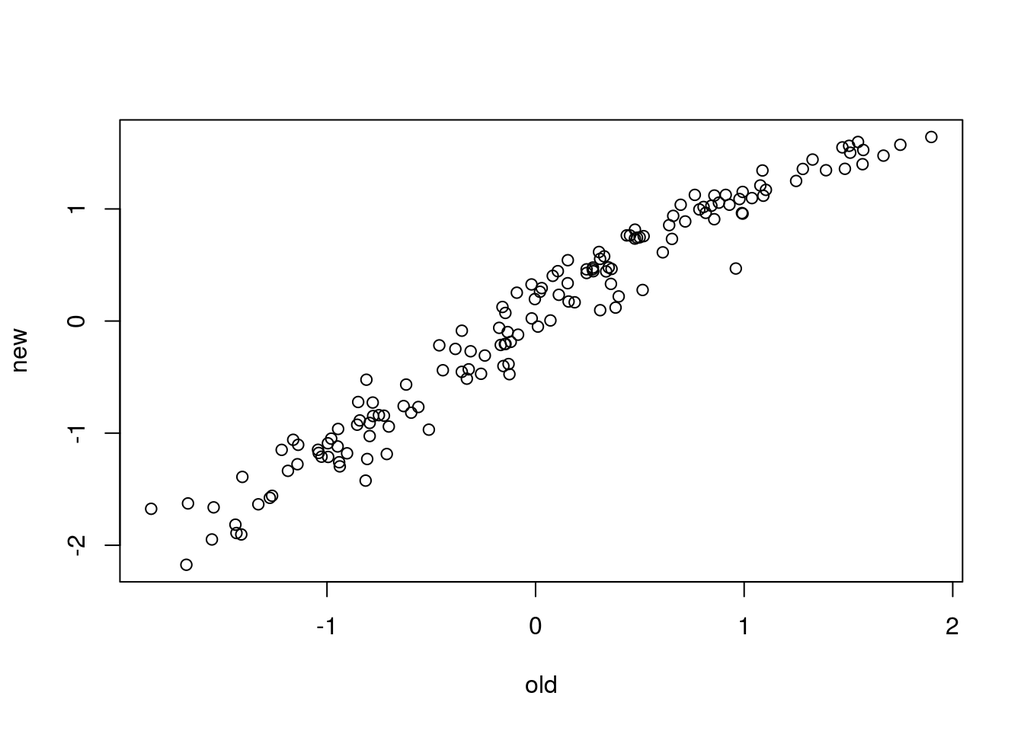

```r
old=apply(HappyDemo[,c("Electoral","Functioning","Politicalparticipation","Politicalculture","Civilliberties")],1,mean)
new=HappyDemo$democracia
plot(old,new)
```

```r
cor(old,new)
```

```
## [1] 0.9783288
```

[VOLVER A CONTENIDOS](https://politicaygobiernopucp.github.io/estadistica_anapol2/)